# Project:TMDB movie data analysis

> - Introduction
> - Data Wrangling
> - Exploratory Data Analysis
> - Conclusions

## Introduction

### Dataset Description

> The Movie Database (TMDb) is a popular, user editable database for movies and TV shows.This data set contains information about 10,000 movies collected from The Movie Database (TMDb), including user ratings and revenue.

### Question(s) for Analysis

- Which genres are most popular from year to year?
- What kinds of properties are associated with movies that have high revenues?

### Data Gathering

In the cell below, i have downloaded the piece of data needed for this project which was gotten from udacity.com

```python
import pandas as pd
import numpy as np
import seaborn as sns
import matplotlib.pyplot as plt
import matplotlib.patches as mpatches
from matplotlib import rcParams

%matplotlib inline
```

```python
data_frame = pd.read_csv('tmdb-movies.csv')
```

## Data Wrangling

### General Properties

```python
data_frame.sample(10)
```

|  | id | imdb_id | popularity | budget | revenue | original_title | cast | homepage | director | tagline | ... | overview | runtime | genres | production_companies | release_date | vote_count | vote_average | release_year | budget_adj | revenue_adj |
| --- | --- | --- | --- | --- | --- | --- | --- | --- | --- | --- | --- | --- | --- | --- | --- | --- | --- | --- | --- | --- | --- |
| 707 | 193610 | tt2203939 | 1.900038 | 40000000 | 196781193 | The Other Woman | Cameron Diaz\|Leslie Mann\|Kate Upton\|Don Johnso... | NaN | Nick Cassavetes | The oddest friends are about to get even | ... | After discovering her boyfriend is married, Ca... | 109 | Comedy\|Romance | Twentieth Century Fox Film Corporation\|LBI Pro... | 4/16/14 | 1056 | 6.2 | 2014 | 3.684364e+07 | 1.812534e+08 |
| 10638 | 24923 | tt0071396 | 0.144305 | 0 | 0 | Messiah of Evil | Michael Greer\|Marianna Hill\|Joy Bang\|Anitra Fo... | NaN | Willard Huyck\|Gloria Katz | Terror you won't want to remember - In a film ... | ... | A young woman goes searching for her missing a... | 90 | Mystery\|Horror | International Cine Film Corp.\|V/M Productions | 1/1/73 | 14 | 6.9 | 1973 | 0.000000e+00 | 0.000000e+00 |
| 3887 | 51261 | tt1059887 | 0.040690 | 0 | 0 | The Legend of Awesomest Maximus | Will Sasso\|Rip Torn\|Kristanna Loken\|Ian Zierin... | NaN | Jeff Kanew | NaN | ... | Spoof of sword-and-sandal flicks such as “Gl... | 87 | Comedy | NaN | 8/5/11 | 11 | 5.2 | 2011 | 0.000000e+00 | 0.000000e+00 |
| 9046 | 9440 | tt0119942 | 0.563458 | 65000000 | 0 | Primary Colors | John Travolta\|Emma Thompson\|Billy Bob Thornton... | NaN | Mike Nichols | What went down on the way to the top. | ... | In this adaptation of the best-selling roman Ã... | 143 | Comedy\|Drama | Universal Pictures\|Mutual Film Company | 3/20/98 | 49 | 5.7 | 1998 | 8.695021e+07 | 0.000000e+00 |
| 9940 | 1485 | tt0067128 | 0.454248 | 750000 | 0 | Get Carter | Michael Caine\|Ian Hendry\|Britt Ekland\|John Osb... | NaN | Mike Hodges | What happens when a professional killer violat... | ... | Michael Caine is Jack Carter, a small-time hoo... | 112 | Crime\|Thriller | Metro-Goldwyn-Mayer (MGM) | 3/3/71 | 52 | 7.0 | 1971 | 4.038896e+06 | 0.000000e+00 |
| 4604 | 84332 | tt1862079 | 0.408010 | 750000 | 4007792 | Safety Not Guaranteed | Aubrey Plaza\|Mark Duplass\|Jake Johnson\|Karan S... | NaN | Colin Trevorrow | What would you go back for? | ... | Three magazine employees head out on an assign... | 85 | Comedy\|Romance\|Science Fiction\|Drama | Duplass Brothers Productions\|Big Beach Films | 6/8/12 | 341 | 6.7 | 2012 | 7.123082e+05 | 3.806378e+06 |
| 7974 | 10179 | tt0087451 | 0.202992 | 9000000 | 0 | The Ice Pirates | Robert Urich\|Mary Crosby\|Michael D. Roberts\|An... | NaN | Stewart Raffill | A totally SPACED adventure! ...You have to be ... | ... | The time is the distant future, where by far t... | 91 | Action\|Science Fiction\|Comedy | JF Productions\|Metro-Goldwyn-Mayer (MGM) | 3/16/84 | 22 | 5.0 | 1984 | 1.889138e+07 | 0.000000e+00 |
| 4745 | 102630 | tt1919090 | 0.221582 | 2000000 | 0 | Stash House | Dolph Lundgren\|Briana Evigan\|Sean Faris\|Jon Hu... | NaN | Eduardo Rodríguez | Every villain has his day. | ... | Dave and Emma have found the perfect house, un... | 95 | Action\|Thriller | After Dark Films | 5/11/12 | 12 | 5.1 | 2012 | 1.899489e+06 | 0.000000e+00 |
| 7300 | 33638 | tt0068853 | 0.130781 | 0 | 0 | The Life and Times of Judge Roy Bean | Paul Newman\|Jacqueline Bisset\|Ned Beatty\|Antho... | NaN | John Huston | If this story ain't true... it shoulda been! | ... | Outlaw and self-appointed lawmaker, Judge Roy ... | 120 | Action\|Comedy\|Western | First Artists\|National General Pictures | 12/18/72 | 11 | 6.0 | 1972 | 0.000000e+00 | 0.000000e+00 |
| 1337 | 14140 | tt0076137 | 0.905657 | 0 | 0 | Herbie Goes To Monte Carlo | Dean Jones\|Don Knotts\|Julie Sommars\|Jacques Ma... | NaN | Vincent McEveety | The Love Bug falls 'hood-over-wheels' for a cl... | ... | Herbie, the Volkswagen Beetle with a mind of i... | 105 | Romance\|Comedy\|Family\|Action\|Adventure | Walt Disney Productions | 6/24/77 | 36 | 6.4 | 1977 | 0.000000e+00 | 0.000000e+00 |

10 rows × 21 columns

```python
data_frame.shape
```

```
(10866, 21)
```

### Accessing Data

```python
for i,j in enumerate(data_frame):
    print(i,j)#index of each columns
```

```
0 id
1 imdb_id
2 popularity
3 budget
4 revenue
5 original_title
6 cast
7 homepage
8 director
9 tagline
10 keywords
11 overview
12 runtime
13 genres
14 production_companies
15 release_date
16 vote_count
17 vote_average
18 release_year
19 budget_adj
20 revenue_adj
```

```python
data_frame.info()
```

```
<class 'pandas.core.frame.DataFrame'>
RangeIndex: 10866 entries, 0 to 10865
Data columns (total 21 columns):
 #   Column                Non-Null Count  Dtype
---  ------                --------------  -----
 0   id                    10866 non-null  int64
 1   imdb_id               10856 non-null  object
 2   popularity            10866 non-null  float64
 3   budget                10866 non-null  int64
 4   revenue               10866 non-null  int64
 5   original_title        10866 non-null  object
 6   cast                  10790 non-null  object
 7   homepage              2936 non-null   object
 8   director              10822 non-null  object
 9   tagline               8042 non-null   object
 10  keywords              9373 non-null   object
 11  overview              10862 non-null  object
 12  runtime               10866 non-null  int64
 13  genres                10843 non-null  object
 14  production_companies  9836 non-null   object
 15  release_date          10866 non-null  object
 16  vote_count            10866 non-null  int64
 17  vote_average          10866 non-null  float64
 18  release_year          10866 non-null  int64
 19  budget_adj            10866 non-null  float64
 20  revenue_adj           10866 non-null  float64
dtypes: float64(4), int64(6), object(11)
memory usage: 1.3+ MB
```

```python
data_frame.isnull().sum()
```

```
id                         0
imdb_id                   10
popularity                 0
budget                     0
revenue                    0
original_title             0
cast                      76
homepage                7930
director                  44
tagline                 2824
keywords                1493
overview                   4
runtime                    0
genres                    23
production_companies    1030
release_date               0
vote_count                 0
vote_average               0
release_year               0
budget_adj                 0
revenue_adj                0
dtype: int64
```

```python
data_frame.duplicated().sum()
```

```
1
```

```python
data_frame.genres
```

```
0        Action|Adventure|Science Fiction|Thriller
1        Action|Adventure|Science Fiction|Thriller
2               Adventure|Science Fiction|Thriller
3         Action|Adventure|Science Fiction|Fantasy
4                            Action|Crime|Thriller
                           ...
10861                                  Documentary
10862                       Action|Adventure|Drama
10863                               Mystery|Comedy
10864                                Action|Comedy
10865                                       Horror
Name: genres, Length: 10866, dtype: object
```

### Quality issues

1.wrong data type for release date

2.Duplicated value present

3.Null values in production_companies, genres, cast, homepage, director, tagline, keywords, overview and imdb_id

4.some values in revenue and budget columns is zero

### Data Cleaning

```python
#making copy of the original data
data = data_frame.copy()
```

```python
#dropping null valuues
data_frame.dropna(inplace=True)
```

```python
data_frame.drop_duplicates(inplace=True)#dropping duplicates
```

```python
#droping all entries with 0 as input
data_frame = data_frame[(data_frame != 0).all(1)]
```

```python
#converting release date column to date time
data_frame['release_date'] = pd.to_datetime(data_frame['release_date'])
```

```python
#since i won't be using some of these columns, i'll just drop them.
data_frame.drop(['homepage', 'tagline', 'keywords'], axis=1, inplace=True)
```

#### Test

```python
data_frame.sample()
```

|  | id | imdb_id | popularity | budget | revenue | original_title | cast | director | overview | runtime | genres | production_companies | release_date | vote_count | vote_average | release_year | budget_adj | revenue_adj |
| --- | --- | --- | --- | --- | --- | --- | --- | --- | --- | --- | --- | --- | --- | --- | --- | --- | --- | --- |
| 1994 | 23437 | tt1179056 | 1.074308 | 35000000 | 115664037 | A Nightmare on Elm Street | Jackie Earle Haley\|Katie Cassidy\|Kyle Gallner\|... | Samuel Bayer | The film that brings back horror icon Freddy K... | 95 | Horror\|Mystery\|Thriller | New Line Cinema\|Platinum Dunes | 2010-04-30 | 423 | 5.5 | 2010 | 35000000.0 | 115664037.0 |

```python
#checking if any 0 is in data_frame
count = 0
for i in data_frame.revenue:
    if i == 0:
        count += 1
print(count)
```

```
0
```

```python
#checking dropped columns
data_frame.columns
```

```
Index(['id', 'imdb_id', 'popularity', 'budget', 'revenue', 'original_title',
       'cast', 'director', 'overview', 'runtime', 'genres',
       'production_companies', 'release_date', 'vote_count', 'vote_average',
       'release_year', 'budget_adj', 'revenue_adj'],
      dtype='object')
```

```python
b = ('homepage', 'tagline', 'keywords')
assert b not in data_frame.columns
```

```python
#checking duplicated values
data_frame.duplicated().sum()
```

```
0
```

```python
#checking for null values
data_frame.isnull().sum()
```

```
id                      0
imdb_id                 0
popularity              0
budget                  0
revenue                 0
original_title          0
cast                    0
director                0
overview                0
runtime                 0
genres                  0
production_companies    0
release_date            0
vote_count              0
vote_average            0
release_year            0
budget_adj              0
revenue_adj             0
dtype: int64
```

```python
data_frame.shape
```

```
(1287, 18)
```

### Storing Data

Saving gathered, assessed, and cleaned master dataset to a CSV file named "tmdb-movies-clean.csv".

```python
data_frame.to_csv("TMDB-movies-clean.csv", index=False)
```

```python
df = pd.read_csv('TMDB-movies-clean.csv')
```

## Exploratory Data Analysis

#### What kinds of properties are associated with movies that have high revenues?

> dependant variable here is revenue

##### is vote count associated with high revenu?

```python
df.describe().vote_count
```

```
count    1287.000000
mean      947.266511
std      1255.476215
min        10.000000
25%       179.000000
50%       439.000000
75%      1173.000000
max      9767.000000
Name: vote_count, dtype: float64
```

```python
df.shape
```

```
(1287, 18)
```

```python
#creating a bin edge value and name for a new column
vals = [10, 179, 439, 1173, 9767]
val_names = ['poor', 'moderate', 'mod_high', 'high']
```

```python
#creating new column
data_frame['vote_levels'] = pd.cut(data_frame['vote_count'], vals, labels=val_names)
```

```python
data_frame.head(2)
```

|  | id | imdb_id | popularity | budget | revenue | original_title | cast | director | overview | runtime | genres | production_companies | release_date | vote_count | vote_average | release_year | budget_adj | revenue_adj | vote_levels |
| --- | --- | --- | --- | --- | --- | --- | --- | --- | --- | --- | --- | --- | --- | --- | --- | --- | --- | --- | --- |
| 0 | 135397 | tt0369610 | 32.985763 | 150000000 | 1513528810 | Jurassic World | Chris Pratt\|Bryce Dallas Howard\|Irrfan Khan\|Vi... | Colin Trevorrow | Twenty-two years after the events of Jurassic ... | 124 | Action\|Adventure\|Science Fiction\|Thriller | Universal Studios\|Amblin Entertainment\|Legenda... | 2015-06-09 | 5562 | 6.5 | 2015 | 1.379999e+08 | 1.392446e+09 | high |
| 1 | 76341 | tt1392190 | 28.419936 | 150000000 | 378436354 | Mad Max: Fury Road | Tom Hardy\|Charlize Theron\|Hugh Keays-Byrne\|Nic... | George Miller | An apocalyptic story set in the furthest reach... | 120 | Action\|Adventure\|Science Fiction\|Thriller | Village Roadshow Pictures\|Kennedy Miller Produ... | 2015-05-13 | 6185 | 7.1 | 2015 | 1.379999e+08 | 3.481613e+08 | high |

```python
data_frame.groupby('vote_levels').mean().revenue
```

```
vote_levels
poor        2.529717e+07
moderate    7.326995e+07
mod_high    1.477218e+08
high        4.588060e+08
Name: revenue, dtype: float64
```

```python
#for 2010 inflation rate
data_frame.groupby('vote_levels').mean().revenue_adj
```

```
vote_levels
poor        2.850896e+07
moderate    9.746905e+07
mod_high    1.682744e+08
high        5.026439e+08
Name: revenue_adj, dtype: float64
```

```python
#does high vote count mean high popularity of a movie?
data_frame.groupby('vote_levels').mean().popularity
```

```
vote_levels
poor        0.549302
moderate    1.021225
mod_high    1.593226
high        3.981535
Name: popularity, dtype: float64
```

```python
#is their is correlation between budget and revenue?
data_frame[['budget', 'revenue']].mean()
```

```
budget     5.200349e+07
revenue    1.762444e+08
dtype: float64
```

```python
data_frame[['budget_adj', 'revenue_adj']].mean()
```

```
budget_adj     5.462994e+07
revenue_adj    1.991775e+08
dtype: float64
```

### Which genres are most popular from year to year?

dependant variable here is genre

```python
print(data_frame['popularity'].min())
print(data_frame['popularity'].median())
print(data_frame['popularity'].max())
```

```
0.010334999999999999
1.152354
32.985763
```

```python
#selecting popularity greater than or equal to 15 which is almost at the highest level
bf = data_frame.query('popularity >= 12')
```

```python
bf[['genres', 'release_year']]
```

|  | genres | release_year |
| --- | --- | --- |
| 0 | Action\|Adventure\|Science Fiction\|Thriller | 2015 |
| 1 | Action\|Adventure\|Science Fiction\|Thriller | 2015 |
| 2 | Adventure\|Science Fiction\|Thriller | 2015 |
| 629 | Adventure\|Drama\|Science Fiction | 2014 |
| 630 | Action\|Science Fiction\|Adventure | 2014 |
| 631 | Action\|Adventure\|Science Fiction | 2014 |
| 1329 | Adventure\|Action\|Science Fiction | 1977 |

```python
#movies with popularity >= 10
bf[['genres', 'release_year', 'popularity' , 'original_title', 'revenue', 'budget']]
```

|  | genres | release_year | popularity | original_title | revenue | budget |
| --- | --- | --- | --- | --- | --- | --- |
| 0 | Action\|Adventure\|Science Fiction\|Thriller | 2015 | 32.985763 | Jurassic World | 1513528810 | 150000000 |
| 1 | Action\|Adventure\|Science Fiction\|Thriller | 2015 | 28.419936 | Mad Max: Fury Road | 378436354 | 150000000 |
| 2 | Adventure\|Science Fiction\|Thriller | 2015 | 13.112507 | Insurgent | 295238201 | 110000000 |
| 629 | Adventure\|Drama\|Science Fiction | 2014 | 24.949134 | Interstellar | 621752480 | 165000000 |
| 630 | Action\|Science Fiction\|Adventure | 2014 | 14.311205 | Guardians of the Galaxy | 773312399 | 170000000 |
| 631 | Action\|Adventure\|Science Fiction | 2014 | 12.971027 | Captain America: The Winter Soldier | 714766572 | 170000000 |
| 1329 | Adventure\|Action\|Science Fiction | 1977 | 12.037933 | Star Wars | 775398007 | 11000000 |

### Visualizations

#### Univariate

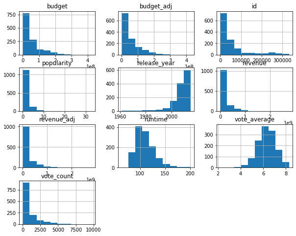

```python
#getting overview of the entire data
data_frame.hist(figsize=(10, 8));
```

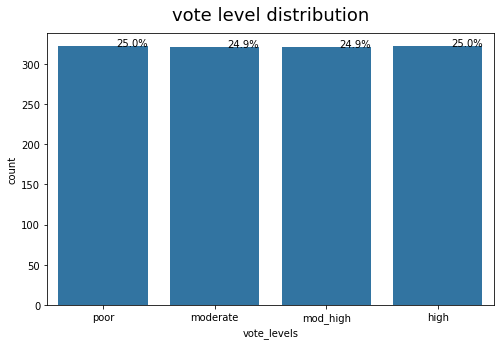

```python
plt.figure(figsize=[8, 5])
dc = sns.color_palette()[0]
vl = sns.countplot(data = data_frame, x = 'vote_levels', color = dc)

total = float(len(data_frame))
for p in vl.patches:
    percentage = '{:.1f}%'.format(100 * p.get_height()/total)
    x = p.get_x() + p.get_width()
    y = p.get_height()
    vl.annotate(percentage, (x, y),ha='right')
plt.title('vote level distribution', fontsize=18, y=1.025)
plt.show()
```

next, i'll check movie release counts from each year

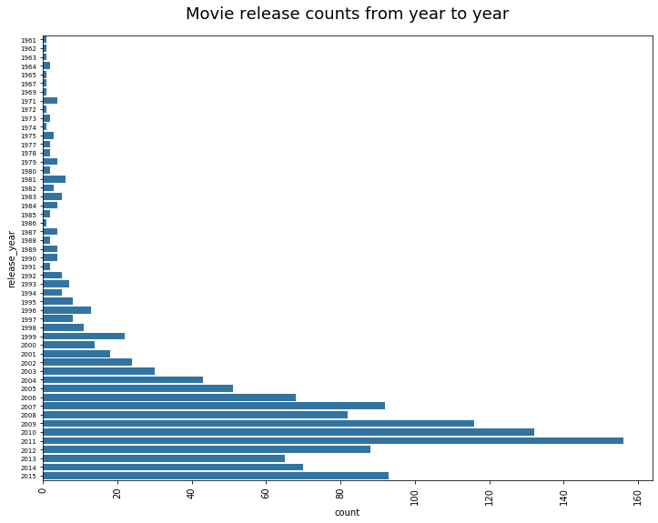

```python
plt.figure(figsize=[12, 9])

dc = sns.color_palette()[0]
vl = sns.countplot(data = data_frame, y = 'release_year', color = dc)

plt.title("Movie release counts from year to year", fontsize=18, y=1.025)
plt.yticks(fontsize=7)
plt.xticks(rotation="vertical")
plt.show()
```

it seems most movies were released in the 2000s than the 90s and this really peaked in 2010 and 2011

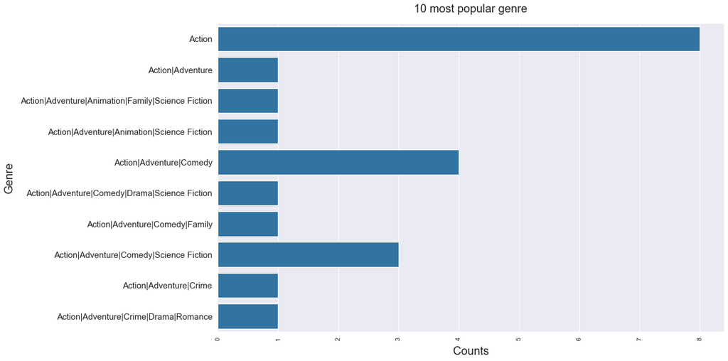

```python
top_genres = data_frame["genres"].value_counts().sort_index()[:10]

rcParams['figure.figsize'] = 16,10
sns.barplot(x=top_genres, y=top_genres.index, color=dc)
plt.title('10 most popular genre', fontsize=20, y=1.025)
plt.xlabel('Counts', labelpad=10, fontsize=20)
plt.ylabel('Genre', labelpad=10, fontsize=20)
plt.yticks(fontsize=15)
plt.xticks(rotation=90);
```

### Bivariate

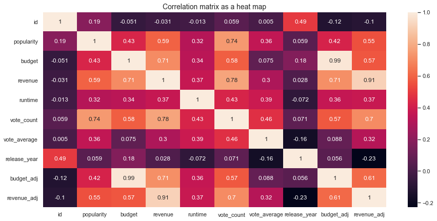

```python
cor = data_frame.corr()

sns.set(rc={'figure.figsize':(15,7)})
sns.heatmap(cor, annot=True)

plt.title('Correlation matrix as a heat map', fontsize=14, y=1.025)
plt.show();
```

Looking at our main variable of interest, revenue there seem to be a strong correlation between it and popularity, budget and vote_count; and a slightly moderate correlation between it and runtime with a weak correlation to release year.

i'll plot this in a scatter_matrix for anothe view

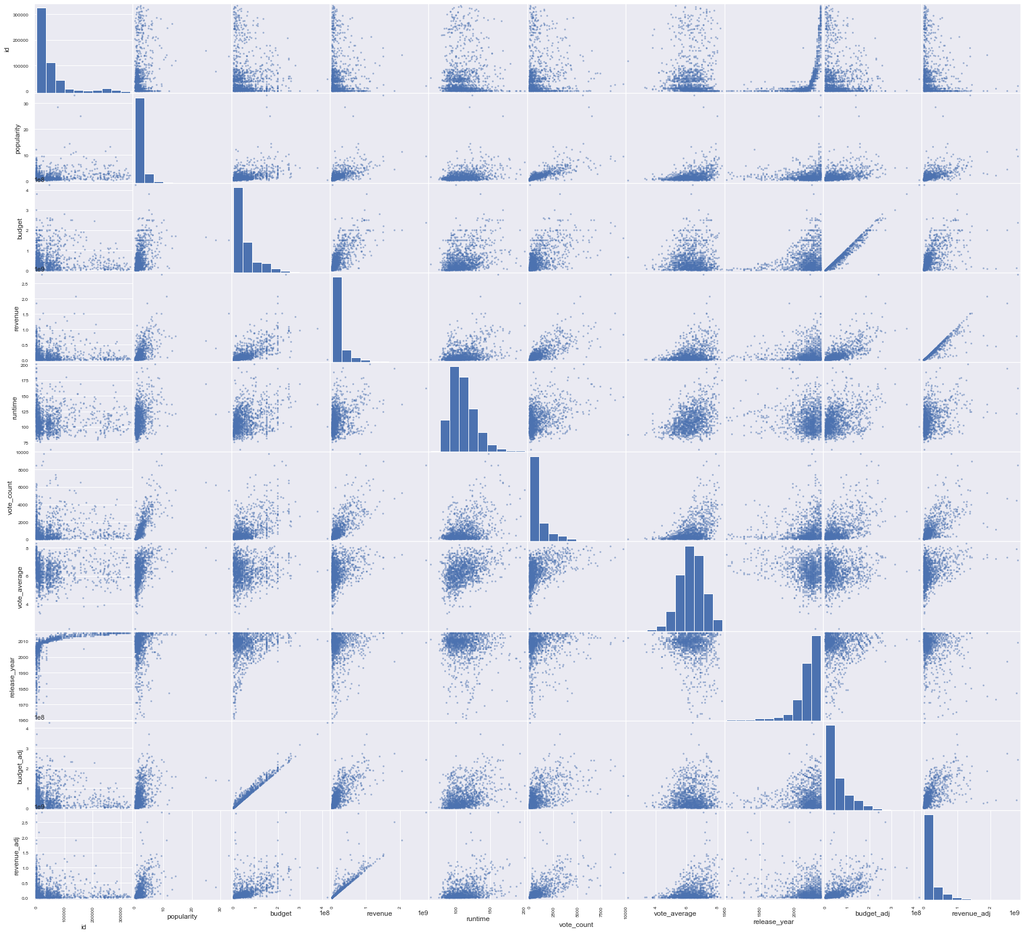

```python
pd.plotting.scatter_matrix(data_frame, figsize=(30,28));
```

I'll start by exploring each of these relations mentioned above further, starting of revenue vs popularity.

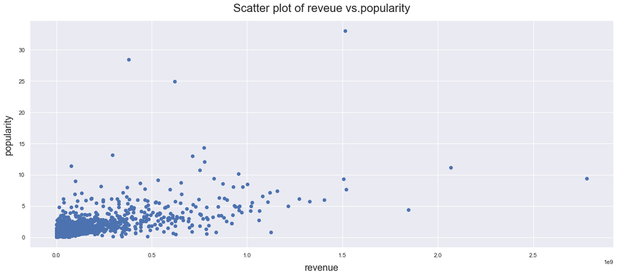

```python
plt.figure(figsize = [20, 8]);
plt.scatter(data = data_frame, x ='revenue' , y = 'popularity')
plt.title('Scatter plot of reveue vs.popularity', fontsize=22, y=1.025)
plt.xlabel('revenue', labelpad=10, fontsize=18)
plt.ylabel('popularity', labelpad=10, fontsize=18)


plt.show();
```

As expected, there is a strong positive correlation between revenue and popularity. that means in most cases, popular movies tend to generate high revenue.

next, i will explore the correlation between vote level and revenue

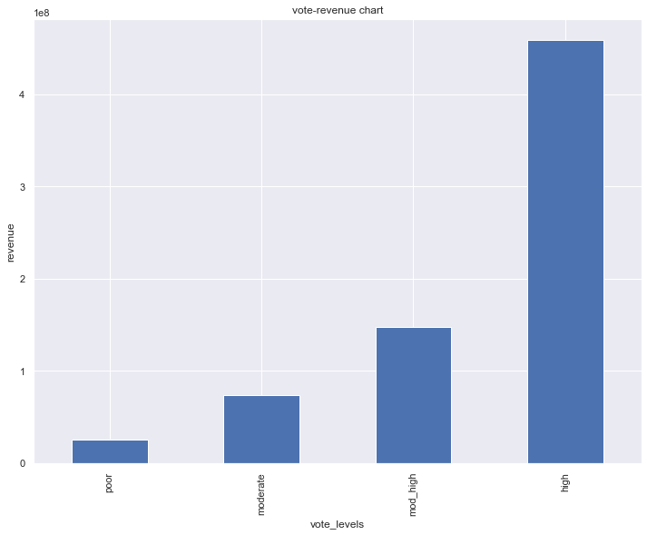

```python
#grouping movies with revenue by votes
plt.figure(figsize=[12, 9])
data_frame.groupby("vote_levels").revenue.mean().plot(kind='bar', y='revenue', title='vote-revenue chart');
plt.ylabel("revenue");
```

the above chart represents vote count and revenue, from what can be observed it is clear that most movies with high votes generated high revenue just as observed from the heatmap

i will also view this in a lineplot

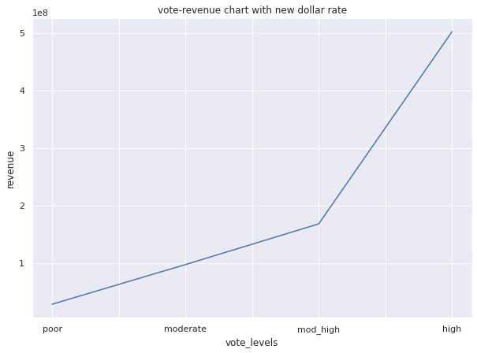

```python
plt.figure(figsize=[10, 7])
#as of 2010 dollar rate
data_frame.groupby("vote_levels").revenue_adj.mean().plot(kind='line', title='vote-revenue chart with new dollar rate');
plt.ylabel("revenue");
```

this show that the higher the vote count of a movie, the higher the revenue generated next, i will explore the correlation between revenue and runtime

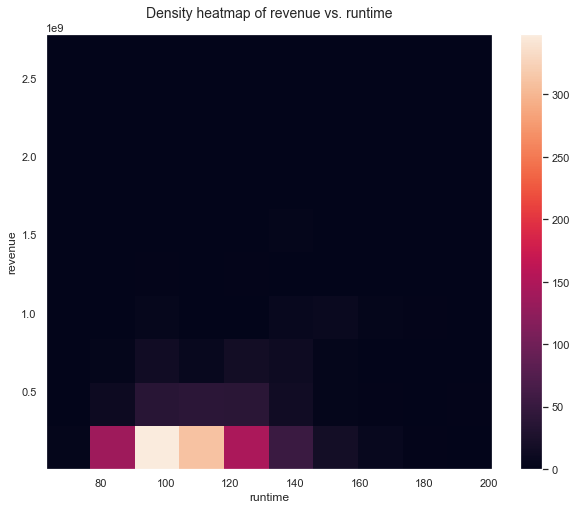

```python
# density heatmap of revenue vs. runtime
plt.figure(figsize = [10, 8])
plt.hist2d(data = data_frame, x ='runtime' , y = 'revenue')
plt.title('Density heatmap of revenue vs. runtime', fontsize=14, y=1.025)
plt.xlabel('runtime')
plt.ylabel('revenue')
plt.colorbar()
plt.show()
```

Just as observed in the correlation matrix, there is a slightly moderate strong correlation between revenue and runtime, so on average, movies that generated high revenue tend to have longer runtime.

now i will check which year had the most movie release

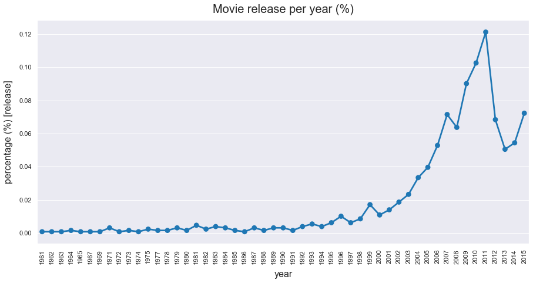

```python
#year with most movie release
release_per_year = (data_frame['release_year'].value_counts().sort_index())/data_frame.shape[0]
# Point plot for yearly release
sns.pointplot(x=release_per_year.index, y=release_per_year.values, color = dc);
plt.title('Movie release per year (%)', fontsize=20, y=1.015)
plt.xlabel('year', labelpad=10, fontsize=16)
plt.ylabel('percentage (%) [release]', labelpad=10, fontsize=16);
plt.xticks(rotation='vertical');
```

i will now explore the correlation between budget and revenue

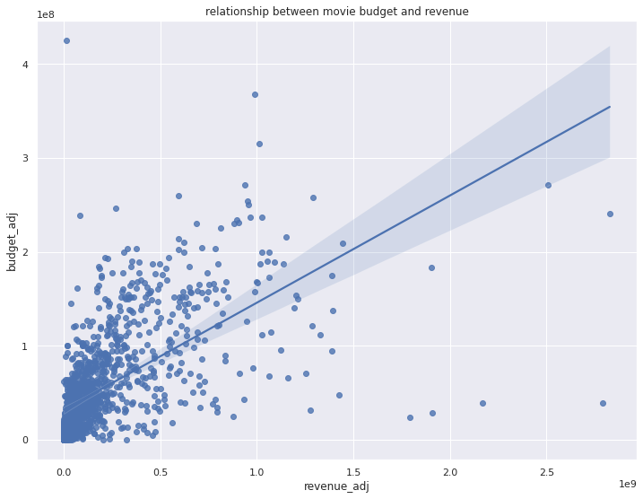

```python
# is there a correllation between high budget movies and high revenue?
plt.figure(figsize=[12, 9])
sns.regplot(x='revenue_adj', y='budget_adj', data=data_frame).set(title='relationship between movie budget and revenue');
```

it seems in most cases, high budget movies generate high revenue since it has an upward regression line

### Multivariate

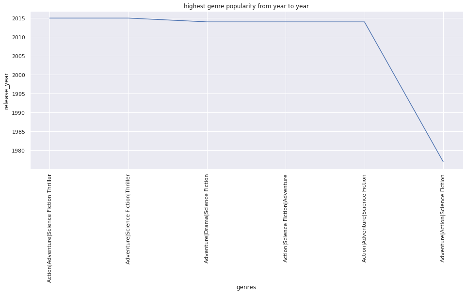

```python
def gen_pop(gen=bf['genres'], year=bf['release_year']):
    rcParams['figure.figsize'] = 16,6
    g = sns.lineplot(x=gen, y=year, data=data_frame) .set(title='highest genre popularity from year to year');
    plt.xticks(rotation='vertical')
    plt.show()


gen_pop()
```

```python
data_frame.describe().revenue
```

```
count    1.287000e+03
mean     1.762444e+08
std      2.538156e+08
min      4.300000e+01
25%      2.565097e+07
50%      8.208716e+07
75%      2.140694e+08
max      2.781506e+09
Name: revenue, dtype: float64
```

```python
li = [4.300000e+01, 2.565097e+07, 8.208716e+07, 2.140694e+08, 2.781506e+09]
li_names = ['low rev', 'mod rev', 'mod_high rev', 'high rev']
rev_lev = pd.cut(data_frame['revenue'], li, labels=li_names)
```

```python
avg_runtime = data_frame.groupby(["vote_levels"]).agg(mean_runtime=("runtime", "mean"))
print(avg_runtime)
```

```
             mean_runtime
vote_levels
poor           103.624224
moderate       105.735202
mod_high       110.485981
high           121.288820
```

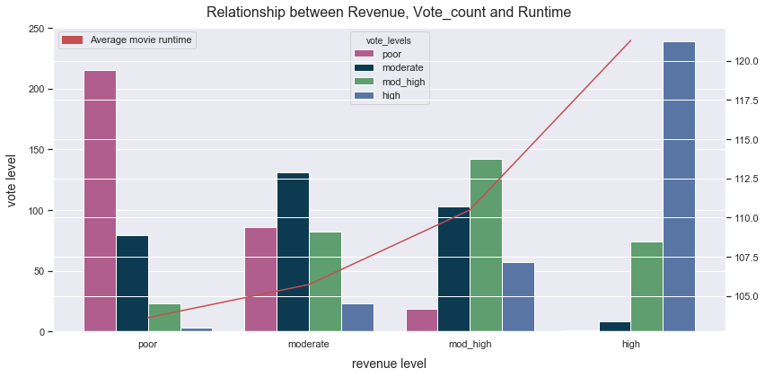

```python
rcParams['figure.figsize'] = 12,6
g = sns.countplot(data=data_frame, x=rev_lev, hue='vote_levels', palette=['#bc5090', '#003f5c','g', 'b'])
plt.title('Relationship between Revenue, Vote_count and Runtime', fontsize=16, y=1.015)
plt.xlabel('revenue level', labelpad=10, fontsize=14)
plt.ylabel('vote level', labelpad=10, fontsize=14)


#creating secondary y axis
ax = g.twinx()
ax.plot(avg_runtime, color='r')

# Creating artists specifically for adding to the legend (Proxy artists)
avg_movie_runtime= mpatches.Patch(color='r', label='Average movie runtime')
plt.legend(handles=[avg_movie_runtime])
plt.tight_layout()
plt.show();
```

movies which had poor revenue had a high number of poor votes and it's runtime was shorter, the opposite is the case for movies which generated high revenue.

movies that have high revenue tend to be longer in and have no poor votes with very little people voting it as moderate.

## Conclusions

> Which genres are most popular from year to year?

> What kinds of properties are associated with movies that have high revenues?

From the correlation matrix, variables which had strong correlation to revenue are Popularity, Vote_counts and Budget, appart from these, runtime seem to be also slightly correlated to revenue; in most cases, movies with longer runtime generated high revenue